# eprscope

[figure not shown]

## Overview

[figure not shown]

The key objective of this fully open source package is to bring handy functions corresponding to “everyday” data processing/analysis in the EPR (Electron Paramagnetic Resonance) spectroscopy mainly in chemistry. The package doesn’t want to replace the excellent EPR simulation/processing [EasySpin Toolbox](https://www.easyspin.org/) for [MATLAB](https://www.mathworks.com/products/matlab.html) . Rather, it may be considered like a complimentary package/toolbox with practical functions which have to be otherwise performed by several tools, e.g. like by the acquisition/processing software, supplied by the EPR spectrometer manufacturers (see e.g. [*Xenon/WinEPR*](https://www.bruker.com/en/products-and-solutions/mr/epr-instruments/epr-software.html)) as well as by several other proprietary software platforms like the *MS Office* and/or *Orgin/SigmaPlot/Igor*. Therefore, the `{eprscope}` also tries to reduce such many steps if the above-mentioned software combination is adopted.

## Installation

```r
# So far, the package can be installed by =>

# install.packages("devtools")
# devtools::install_github("jatanRT/eprscope.git")
```

Before the installation, please make sure that you have already followed instructions for the [{nloptr} package installation](https://astamm.github.io/nloptr/) depending on your operating system. This package is required for the proper running of optimization/fitting functions of the `{eprscope}` .

Completely new users or people who haven’t already installed the *R* environment, please consult ➨

1. [the R installation procedure](https://cran.rstudio.com/)
2. [installation of the Rstudio IDE](https://posit.co/download/rstudio-desktop/)
3. [the latest R tools release](https://cran.r-project.org/bin/windows/Rtools/rtools43/rtools.html) **ONLY for WINDOWS OS**

Additionally, **an open-source scientific and technical publishing system** [Quarto](https://quarto.org/) together with [Pandoc](https://pandoc.org/), **a document converter system**, may be needed for sharing the results coming from `{eprscope}` in desired formats like `pdf` , `html` , `docx` , `pptx` or `tex`.

## Usage

In this section couple of examples are shown in order to briefly demonstrate functionality of the package. More detailed description can be found within the package articles/vignettes or documentation examples.

### Reading Files with Instrumental Parameters

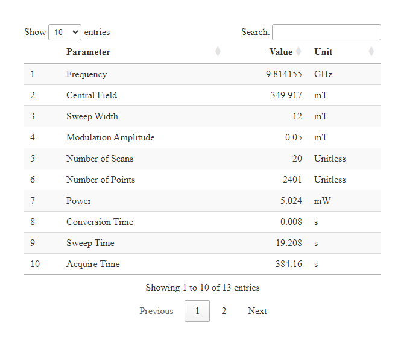

```r
library(eprscope)
#
# built-in package file => "TMPD_specelchem_accu_b.par"
tmpd.params.file <-
  load_data_example(file = "TMPD_specelchem_accu_b.par")
#
# parameters into interactive table (data frame)
tmpd.params.dt <-
  readEPR_params_tabs(path_to_dsc_par = tmpd.params.file,
                      origin = "winepr",
                      interact = "params")
#
# table preview
tmpd.params.dt
```

### Depict Molecular Structures

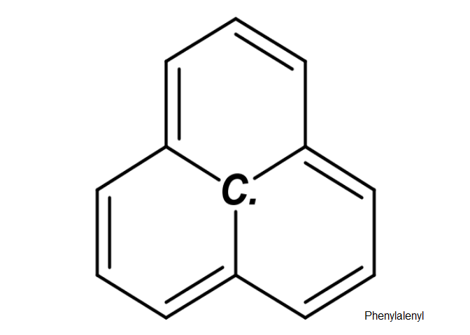

```r
# Phenylalenyl (Perinaphthenyl or PNT) radical from `SMILES`
# "C1([C.]23)=CC=CC2=CC=CC3=CC=C1" code
draw_molecule_by_rcdk(molecule = "C1([C.]23)=CC=CC2=CC=CC3=CC=C1",
                      mol.label = "Phenylalenyl",
                      mol.label.color = "black",
                      mol.label.xy.posit = c(8.8,1.2))
```

### Simulation of Isotropic EPR Spectra

As an example “PNT” radical (see the structure above)

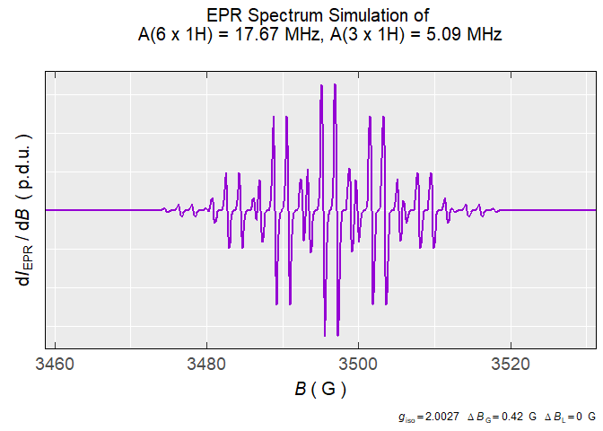

```r
# Simulation of phenylalenyl (perinaphthenyl or PNT) radical,
# see also https://pubs.rsc.org/en/content/articlelanding/2006/CS/b500509b.
# additional experimental/instrumental parameters are not shown,
# and posses their default values => see the corresponding documentation
# of `eval_sim_EPR_iso()` function.
#
simulation.iso <-
  eval_sim_EPR_iso(g.iso = 2.0027,
                   B.unit = "G",
                   nuclear.system = list(list("1H",3,5.09),
                                         list("1H",6,17.67)),
                   natur.abund = T,
                   lineGL.DeltaB = list(0.42,NULL))
#
# simulation spectrum preview in the region from 3462 G to 3528 G
simulation.iso$plot + ggplot2::coord_cartesian(xlim = c(3462,3528))
```

## Help, Questions and Contribution

- [R for Data Science (2e)](https://r4ds.hadley.nz/)
- [ggplot2: Elegant Graphics for Data Analysis (3e)](https://ggplot2-book.org/)
- [Advanced R](https://adv-r.hadley.nz/)
- [POSIT Homepage](https://posit.co/)
- [R Crash Course](https://colauttilab.github.io/RCrashCourse/1_fundamentals.html)
- [Statology R Guides](https://www.statology.org/r-guides/)
- [An Introduction to R](https://intro2r.com/)
- [Introverse](https://sjspielman.github.io/introverse/)
- [Why should I use R ? (Series)](https://www.jumpingrivers.com/blog/comparing-r-excel-data-wrangling/)
- [R to Python Data Wrangling](https://gist.github.com/conormm/fd8b1980c28dd21cfaf6975c86c74d07)
- [Official Contributed Documentation of R](https://cran.r-project.org/other-docs.html)
- [Thi Big Book of R](https://www.bigbookofr.com/)
- Video Tutorial (Series) ➨
  - [Introduction to R Programming for Excel Users](https://www.youtube.com/watch?v=Ekp2mfxQSzw)
  - [Bioinformatics and R Programming](https://www.youtube.com/@LiquidBrain)
  - [R Programming 101](https://www.youtube.com/@RProgramming101)
  - [Equitable Equations](https://www.youtube.com/@EquitableEquations)
  - [R Programming Full Course 2023](https://www.youtube.com/watch?v=Q5g6lYUn6Q4)
  - [Plotting Anything with ggplot2](https://www.youtube.com/watch?v=h29g21z0a68)

Even though the **EPR spectroscopy** is a quite complex field there are some introductory on-line materials which may help to start with this special magnetic resonance method and how to gather the direct structural evidence of unpaired electronic centers within the molecules ➨

- [EasySpin Documentation](https://easyspin.org/easyspin/documentation/)
- EPR LibreTexts in Chemistry
- [NMR Spectroscopy of Organic Compounds (Lesson 10)](https://nmr.group.uochb.cz/en/nmr-organic-compounds)
- [Bruker EPR Instruments](https://www.bruker.com/en/products-and-solutions/mr/epr-instruments.html)
- [EPR Everywhere](https://researchoutreach.org/articles/electron-paramagnetic-resonance-epr-everywhere/)
- [Basic Concepts of EPR](https://epr.ethz.ch/education/basic-concepts-of-epr.html)